# GBSV MC2 – Pattern Detection

Autor:in

Luca Manna

Veröffentlichungsdatum

6. Mai 2026

# 1 Aufgabe: Pattern Detection

**Land:** USA  
**Semester:** FS26

## 1.1 Tag 6 – Technische Implementierung

### 1.1.1 Algorithmus: Canny Edge Detection

Als Eingabe dient ein synthetisches Testbild mit einem Rechteck, einem Kreis und einer diagonalen Linie. Da die Kantengeometrie bekannt ist, laesst sich das Ergebnis jedes Schritts direkt pruefen.

### 1.1.2 Verarbeitungspipeline

| Schritt | Bezeichnung | Aufgabe |
| --- | --- | --- |
| 1 | Gaussian Blur | Rauschunterdrueckung vor der Gradientenberechnung |
| 2 | Sobel Gradient | Gradientenbetrag und Gradientenrichtung pro Pixel |
| 3 | Non-Maximum Suppression (NMS) | Ausdunnung der Kanten auf exakt eine Pixelbreite |
| 4 | Hysteresis Thresholding | Klassifikation in Strong / Weak / kein Kantenpixel |

### 1.1.3 Baseline-Konfiguration

| Parameter | Wert | Rolle |
| --- | --- | --- |
| `kernel_size` | 5 | Fenstergrösse des Gaussian-Filters [Pixel] |
| `sigma` | 1.0 | Standardabweichung des Gaussians |
| `sobel_ksize` | 3 | Kernelgrösse des Sobel-Operators |
| `low_threshold` | 50 | Untere Hysteresegrenze [0-255] |
| `high_threshold` | 150 | Obere Hysteresegrenze [0-255] |

```python
import numpy as np
import matplotlib.pyplot as plt
import cv2
from scipy.ndimage import label

# Baseline-Konfiguration
KERNEL_SIZE = 5
SIGMA = 1.0
SOBEL_KSIZE = 3
LOW_THRESHOLD = 50
HIGH_THRESHOLD = 150
```

### 1.1.4 Synthetisches Testbild

Das Testbild (300 x 300 Pixel, Graustufen) enthaelt drei Strukturen mit unterschiedlichen Kantentypen: - **Rechteck:** gerade horizontale und vertikale Kanten - **Kreis:** gekruemmte Kante mit variabler Richtung - **Diagonale Linie:** schraege Kante bei ca. 10 Grad

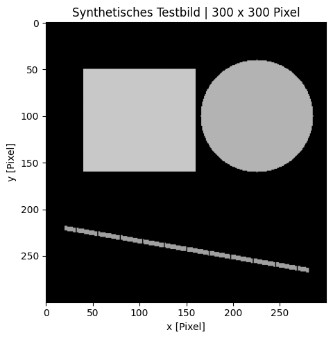

```
Groesse: 300 x 300 Pixel | dtype: uint8 | Wertebereich: [0, 200]
```

```python
H, W = 300, 300
test_img = np.zeros((H, W), dtype=np.uint8)

# Rechteck (oben links)
test_img[50:160, 40:160] = 200

# Kreis (oben rechts)
cy, cx, r = 100, 225, 60
yy, xx = np.ogrid[:H, :W]
test_img[(xx - cx) ** 2 + (yy - cy) ** 2 <= r**2] = 180

# Diagonale Linie (unten, 5 Pixel breit)
steps = 250
ys = np.round(np.linspace(220, 265, steps)).astype(int)
xs = np.round(np.linspace(20, 280, steps)).astype(int)
for dy in [-2, -1, 0, 1, 2]:
    y_clip = np.clip(ys + dy, 0, H - 1)
    test_img[y_clip, xs] = 160

fig, ax = plt.subplots(figsize=(5, 5))
ax.imshow(test_img, cmap="gray", vmin=0, vmax=255)
ax.set_title("Synthetisches Testbild | 300 x 300 Pixel")
ax.set_xlabel("x [Pixel]")
ax.set_ylabel("y [Pixel]")
plt.tight_layout()
plt.show()

print(
    f"Groesse: {W} x {H} Pixel | dtype: {test_img.dtype} "
    f"| Wertebereich: [{test_img.min()}, {test_img.max()}]"
)
```

### 1.1.5 Schritt 1: Gaussian Blur

Ein Gauss-Filter glaettet das Bild, bevor Gradienten berechnet werden. Ohne diesen Schritt wuerden Rauschpixel zu falschen Kanten fuehren. Die Staerke der Glaettung bestimmt `sigma` (Standardabweichung). Ein groesseres `kernel_size` ergibt eine breitere Gewichtungsfunktion und damit staerkere Glaettung.

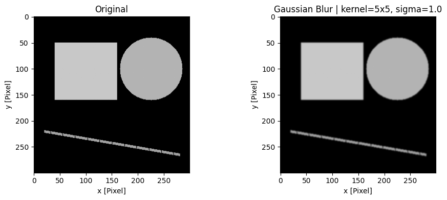

```
Maximale Abweichung zum Original: 101 | Mittlere Abweichung: 2.06
```

```python
blurred = cv2.GaussianBlur(
    test_img,
    ksize=(KERNEL_SIZE, KERNEL_SIZE),
    sigmaX=SIGMA,
)

fig, axes = plt.subplots(1, 2, figsize=(10, 4))
axes[0].imshow(test_img, cmap="gray", vmin=0, vmax=255)
axes[0].set_title("Original")
axes[0].set_xlabel("x [Pixel]")
axes[0].set_ylabel("y [Pixel]")
axes[1].imshow(blurred, cmap="gray", vmin=0, vmax=255)
axes[1].set_title(f"Gaussian Blur | kernel={KERNEL_SIZE}x{KERNEL_SIZE}, sigma={SIGMA}")
axes[1].set_xlabel("x [Pixel]")
axes[1].set_ylabel("y [Pixel]")
plt.tight_layout()
plt.show()

diff = np.abs(test_img.astype(int) - blurred.astype(int))
print(
    f"Maximale Abweichung zum Original: {diff.max()} | "
    f"Mittlere Abweichung: {diff.mean():.2f}"
)
```

### 1.1.6 Schritt 2: Sobel Gradient

Der Sobel-Operator berechnet die partiellen Ableitungen des Bildes in x- und y-Richtung. Aus `dx` und `dy` ergibt sich der Gradientenbetrag (Kantenstärke) und die Gradientenrichtung (Kantenorientierung):

$$|G| = \sqrt{G_x^2 + G_y^2} \qquad \theta = \arctan\!\left(\frac{G_y}{G_x}\right)$$

Die Gradientenrichtung zeigt senkrecht zur Kante und wird im naechsten Schritt fuer die NMS benoetigt.

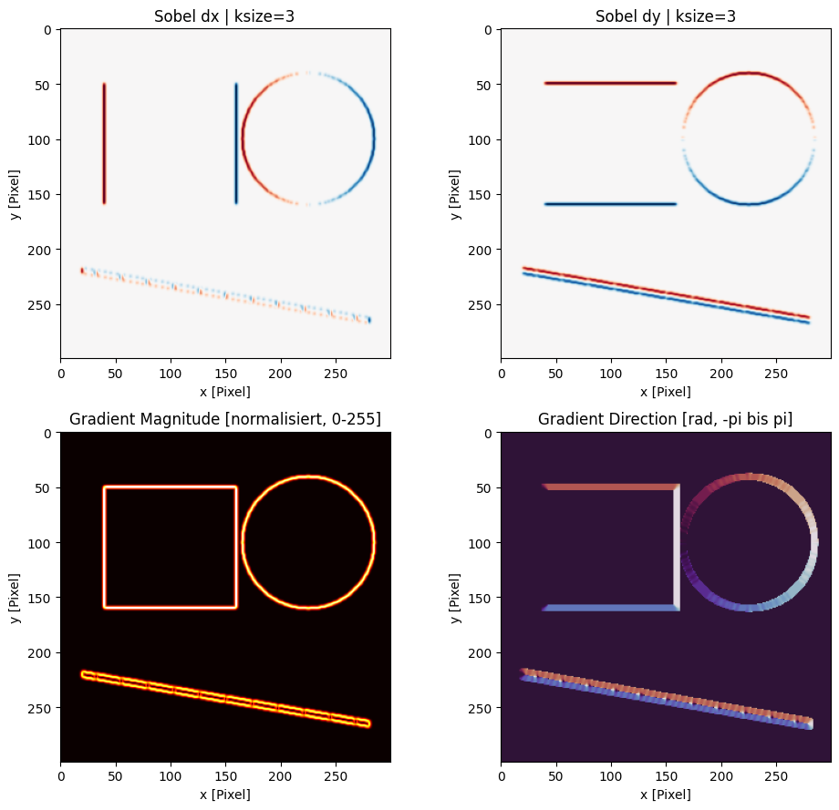

```
Magnitude: max=520.0 | Richtung: [-3.14, 3.14] rad
```

```python
gx = cv2.Sobel(blurred.astype(np.float64), cv2.CV_64F, 1, 0, ksize=SOBEL_KSIZE)
gy = cv2.Sobel(blurred.astype(np.float64), cv2.CV_64F, 0, 1, ksize=SOBEL_KSIZE)

magnitude = np.hypot(gx, gy)
direction = np.arctan2(gy, gx)

# Normalisieren fuer Visualisierung
mag_norm = (magnitude / magnitude.max() * 255).astype(np.uint8)

fig, axes = plt.subplots(2, 2, figsize=(10, 9))
axes[0, 0].imshow(gx, cmap="RdBu_r")
axes[0, 0].set_title(f"Sobel dx | ksize={SOBEL_KSIZE}")
axes[0, 0].set_xlabel("x [Pixel]")
axes[0, 0].set_ylabel("y [Pixel]")
axes[0, 1].imshow(gy, cmap="RdBu_r")
axes[0, 1].set_title(f"Sobel dy | ksize={SOBEL_KSIZE}")
axes[0, 1].set_xlabel("x [Pixel]")
axes[0, 1].set_ylabel("y [Pixel]")
axes[1, 0].imshow(mag_norm, cmap="hot")
axes[1, 0].set_title("Gradient Magnitude [normalisiert, 0-255]")
axes[1, 0].set_xlabel("x [Pixel]")
axes[1, 0].set_ylabel("y [Pixel]")
axes[1, 1].imshow(direction, cmap="twilight")
axes[1, 1].set_title("Gradient Direction [rad, -pi bis pi]")
axes[1, 1].set_xlabel("x [Pixel]")
axes[1, 1].set_ylabel("y [Pixel]")
plt.tight_layout()
plt.show()

print(
    f"Magnitude: max={magnitude.max():.1f} | "
    f"Richtung: [{direction.min():.2f}, {direction.max():.2f}] rad"
)
```

### 1.1.7 Schritt 3: Non-Maximum Suppression (NMS)

Nach der Sobel-Berechnung haben Kanten mehrere Pixel Breite. NMS behaelt pro Kante nur das lokale Maximum in Gradientenrichtung und setzt alle anderen Pixel auf null. Dazu wird die Gradientenrichtung auf vier Sektoren (0, 45, 90, 135 Grad) quantisiert und das aktuelle Pixel mit seinen beiden Nachbarn entlang der Gradientenachse verglichen.

Die folgende Implementierung laeuft pixelweise mit einer Python-Schleife, um jeden Vergleich direkt nachvollziehbar zu machen.

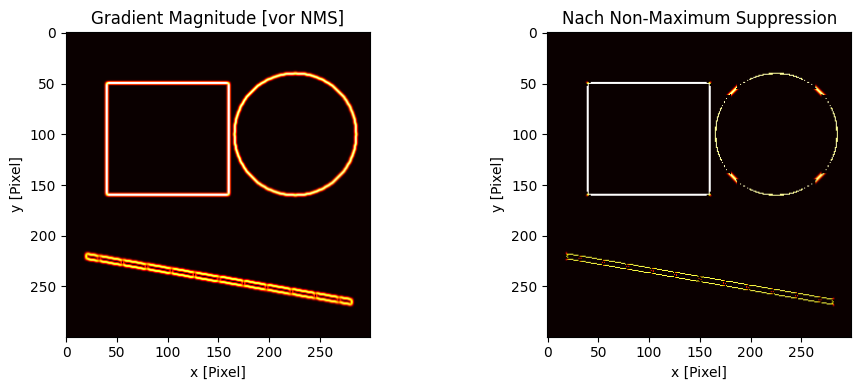

```
Aktive Pixel vor NMS: 8447 | nach NMS: 2128 | Reduktion: 74.8 %
```

```python
def non_maximum_suppression(mag, dirn):
    H, W = mag.shape
    nms = np.zeros_like(mag, dtype=np.float64)
    angle = dirn * 180.0 / np.pi
    angle[angle < 0] += 180

    for i in range(1, H - 1):
        for j in range(1, W - 1):
            a = angle[i, j]
            m = mag[i, j]
            # Zwei Nachbarn entlang der quantisierten Gradientenrichtung
            if (0 <= a < 22.5) or (157.5 <= a <= 180):
                q, r = mag[i, j + 1], mag[i, j - 1]
            elif 22.5 <= a < 67.5:
                q, r = mag[i + 1, j - 1], mag[i - 1, j + 1]
            elif 67.5 <= a < 112.5:
                q, r = mag[i + 1, j], mag[i - 1, j]
            else:
                q, r = mag[i - 1, j - 1], mag[i + 1, j + 1]
            if m >= q and m >= r:
                nms[i, j] = m
    return nms


nms = non_maximum_suppression(magnitude, direction)
nms_norm = (
    (nms / nms.max() * 255).astype(np.uint8) if nms.max() > 0 else nms.astype(np.uint8)
)

fig, axes = plt.subplots(1, 2, figsize=(10, 4))
axes[0].imshow(mag_norm, cmap="hot")
axes[0].set_title("Gradient Magnitude [vor NMS]")
axes[0].set_xlabel("x [Pixel]")
axes[0].set_ylabel("y [Pixel]")
axes[1].imshow(nms_norm, cmap="hot")
axes[1].set_title("Nach Non-Maximum Suppression")
axes[1].set_xlabel("x [Pixel]")
axes[1].set_ylabel("y [Pixel]")
plt.tight_layout()
plt.show()

active_before = np.count_nonzero(mag_norm)
active_after = np.count_nonzero(nms_norm)
print(
    f"Aktive Pixel vor NMS: {active_before} | "
    f"nach NMS: {active_after} | "
    f"Reduktion: {(1 - active_after / active_before) * 100:.1f} %"
)
```

### 1.1.8 Schritt 4: Hysteresis Thresholding

Die NMS-Map enthaelt noch Gradientenwerte aus einem breiten Bereich. Hysteresis Thresholding klassifiziert die Pixel in drei Gruppen: - **Strong Edges:** Gradientenbetrag >= `high_threshold` – sicher eine Kante - **Weak Edges:** `low_threshold` <= Gradientenbetrag < `high_threshold` – nur dann Kante, wenn an eine Strong Edge angrenzend - **Suppressed:** < `low_threshold` – kein Kantenpixel

Die Verbindung von Weak Edges erfolgt ueber Connected-Components-Analyse: eine Weak-Edge-Komponente wird behalten, falls sie mindestens ein Strong-Edge-Pixel enthaelt.

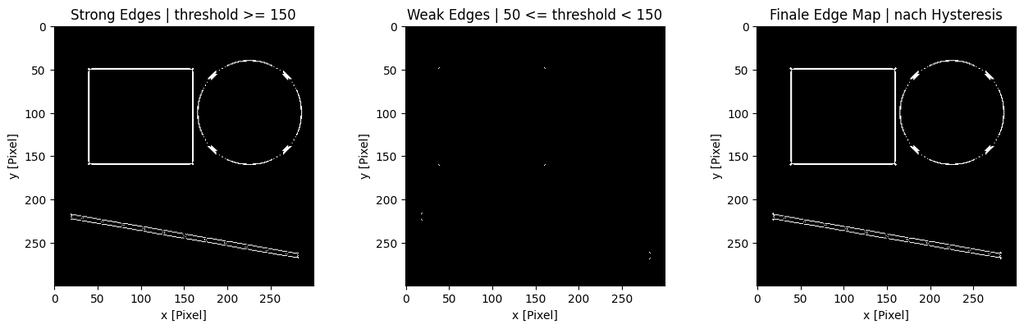

```
Strong Pixels: 1928 | Weak Pixels: 16 | Finale Kantenpixel: 1944
```

```python
def hysteresis_thresholding(nms_map, low, high):
    strong_mask = nms_map >= high
    weak_mask = (nms_map >= low) & (nms_map < high)

    # Verbundene Komponenten auf der Vereinigung beider Masken
    labeled, n_components = label(strong_mask | weak_mask)

    final = np.zeros_like(nms_map, dtype=bool)
    for comp_id in range(1, n_components + 1):
        comp_mask = labeled == comp_id
        # Komponente behalten, wenn mindestens ein Strong-Pixel enthalten
        if np.any(strong_mask[comp_mask]):
            final[comp_mask] = True

    return strong_mask, weak_mask, (final.astype(np.uint8) * 255)


strong_mask, weak_mask, edges = hysteresis_thresholding(
    nms, LOW_THRESHOLD, HIGH_THRESHOLD
)

fig, axes = plt.subplots(1, 3, figsize=(13, 4))
axes[0].imshow(strong_mask, cmap="gray")
axes[0].set_title(f"Strong Edges | threshold >= {HIGH_THRESHOLD}")
axes[0].set_xlabel("x [Pixel]")
axes[0].set_ylabel("y [Pixel]")
axes[1].imshow(weak_mask, cmap="gray")
axes[1].set_title(f"Weak Edges | {LOW_THRESHOLD} <= threshold < {HIGH_THRESHOLD}")
axes[1].set_xlabel("x [Pixel]")
axes[1].set_ylabel("y [Pixel]")
axes[2].imshow(edges, cmap="gray")
axes[2].set_title("Finale Edge Map | nach Hysteresis")
axes[2].set_xlabel("x [Pixel]")
axes[2].set_ylabel("y [Pixel]")
plt.tight_layout()
plt.show()

print(
    f"Strong Pixels: {strong_mask.sum()} | "
    f"Weak Pixels: {weak_mask.sum()} | "
    f"Finale Kantenpixel: {(edges > 0).sum()}"
)
```

### 1.1.9 Verifikation: Vergleich mit cv2.Canny

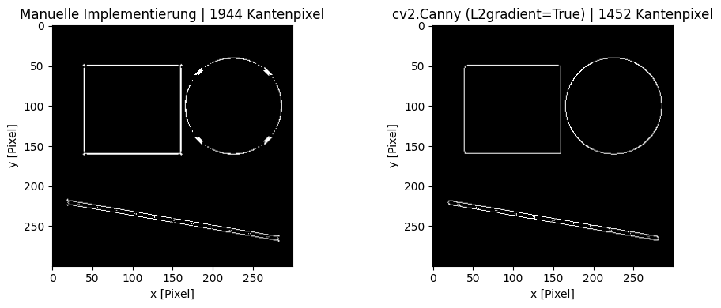

```
Manuelle Implementierung: 1944 Kantenpixel | cv2.Canny: 1452 Kantenpixel
Anzahlverhaeltnis (manuell / cv2): 1.339 | IoU: 0.600
```

```python
edges_cv2 = cv2.Canny(
    blurred,
    threshold1=LOW_THRESHOLD,
    threshold2=HIGH_THRESHOLD,
    L2gradient=True,
)

manual_bin = edges > 0
cv2_bin = edges_cv2 > 0
intersection = np.logical_and(manual_bin, cv2_bin).sum()
union = np.logical_or(manual_bin, cv2_bin).sum()
iou = intersection / union if union > 0 else 0
count_ratio = manual_bin.sum() / cv2_bin.sum() if cv2_bin.sum() > 0 else 0

fig, axes = plt.subplots(1, 2, figsize=(10, 4))
axes[0].imshow(edges, cmap="gray")
axes[0].set_title(f"Manuelle Implementierung | {manual_bin.sum()} Kantenpixel")
axes[0].set_xlabel("x [Pixel]")
axes[0].set_ylabel("y [Pixel]")
axes[1].imshow(edges_cv2, cmap="gray")
axes[1].set_title(f"cv2.Canny (L2gradient=True) | {cv2_bin.sum()} Kantenpixel")
axes[1].set_xlabel("x [Pixel]")
axes[1].set_ylabel("y [Pixel]")
plt.tight_layout()
plt.show()

print(
    f"Manuelle Implementierung: {manual_bin.sum()} Kantenpixel | "
    f"cv2.Canny: {cv2_bin.sum()} Kantenpixel"
)
print(f"Anzahlverhaeltnis (manuell / cv2): {count_ratio:.3f} | IoU: {iou:.3f}")
```

## 1.2 Tag 7 – Daten & Domäne

### 1.2.1 Anwendungsfall

SET ist ein US-amerikanisches Kartenspiel, das 1974 von Marsha Falco entwickelt und durch Set Enterprises (Fountain Hills, Arizona) vertrieben wird. Auf dem Tisch liegen 12 Karten in einer 3x4-Auslage. Alle Spielenden suchen gleichzeitig nach einer gültigen Dreierkombination über vier Eigenschaften: Menge (1, 2 oder 3 Symbole), Farbe (rot, violett, grün), Form (Raute, Balken, Welle) und Füllung (leer, halb, voll). Persönliche Motivation: Ich spiele SET regelmässig mit meiner Freundin und verliere dabei konstant.

Das langfristige Ziel ist ein System, das aus einem Smartphone-Foto der Auslage automatisch das nächste gültige SET vorschlägt. Als ersten Verarbeitungsschritt müssen die 12 Karten im Bild lokalisiert werden. Dieser Tag fokussiert auf die Detektion der Kartenränder als konkreten Anwendungskontext für den Canny-Algorithmus aus Tag 6.

### 1.2.2 Problemstellung

Die 12 Karten in einer realen Smartphone-Aufnahme müssen automatisch lokalisiert werden. Der stärkste lokale Intensitätswechsel im Bild entsteht am Übergang von weisser Kartenfläche zu dunkelgrünem Tischtuch. Diese Kanten sind der direkteste Anhaltspunkt für eine kartenbasierte Lokalisierung.

Drei Herausforderungen für die Kantendetektion in diesem Bild:

1. **Karte-Karte-Grenzen:** Benachbarte Karten haben kaum Kontrast zueinander. Der Algorithmus muss diese schwachen Grenzen von den starken Karte-Untergrund-Kanten unterscheiden.
2. **Ungleichmässige Beleuchtung:** Das Bild zeigt einen Helligkeitsgradienten von oben nach unten, der die effektive Kantenstärke ortsabhängig macht.
3. **Symbole auf den Karten:** Farb- und Formkonturen innerhalb der Karte erzeugen ebenfalls Kanten, die für die Kartenlokalisierung nicht relevant sind.

Der Hysteresis-Mechanismus des Canny-Algorithmus adressiert diese Punkte direkt: mit einem geeigneten `high_threshold` werden nur die starken Karte-Untergrund-Kanten sicher klassifiziert, während schwache interne Kanten unterdrückt werden.

### 1.2.3 Datendefinition, Quelle und Visualisierung

Das Referenzbild ist eine eigene Smartphone-Aufnahme einer regulären SET-Auslage (`mc2/data/IMG_6947.JPG`, 4032 x 3024 Pixel, RGB, JPG-komprimiert). Es zeigt 12 Karten in 3x4-Anordnung auf einer dunkelgrünen Spielmatte und repräsentiert eine typische Spielsituation. Das Bild wurde in Aufgabe 1 (Augmentation, Tag 1) bereits als Referenzbild analysiert; dort wurden photometrische Eigenschaften und Bildcharakteristika beschrieben. Hier dient es als Eingabe für die Kantendetektion.

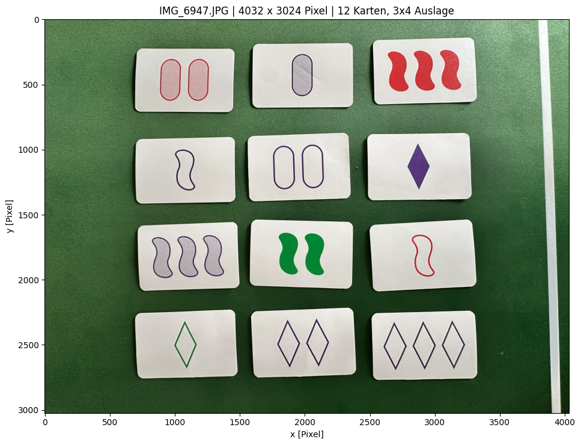

```
Auflösung: 4032 x 3024 Pixel | Kanäle: 3 | dtype: uint8 | Wertebereich: [0, 255]
```

```python
from pathlib import Path
from PIL import Image

IMG_PATH = Path("..") / "data" / "IMG_6947.JPG"
img_pil = Image.open(IMG_PATH)
img = np.array(img_pil)
img_gray = np.array(img_pil.convert("L"))
H, W = img.shape[:2]

fig, ax = plt.subplots(figsize=(10, 7.5))
ax.imshow(img)
ax.set_title(f"IMG_6947.JPG | {W} x {H} Pixel | 12 Karten, 3x4 Auslage")
ax.set_xlabel("x [Pixel]")
ax.set_ylabel("y [Pixel]")
plt.tight_layout()
plt.show()

print(
    f"Auflösung: {W} x {H} Pixel | Kanäle: {img.shape[2]} "
    f"| dtype: {img.dtype} | Wertebereich: [{img.min()}, {img.max()}]"
)
```

**Beobachtungen:**

Die 12 Karten sind vollständig sichtbar und klar gegen den dunkelgrünen Untergrund abgesetzt. Das Bild zeigt eine leichte perspektivische Verkippung und einen Helligkeitsgradienten von oben nach unten. Auf einzelnen Karten sind schwache Glanzlichter erkennbar. Die Kartenränder bilden die dominanten Kanten im Bild und sind der natürliche Zielpunkt für den Canny-Algorithmus.

### 1.2.4 Identifizierte Bildstruktur

Zur Verifikation wird ein repräsentativer Bildausschnitt mit einem Kartenrand analysiert und ein Intensitätsprofil quer über den Rand dargestellt.

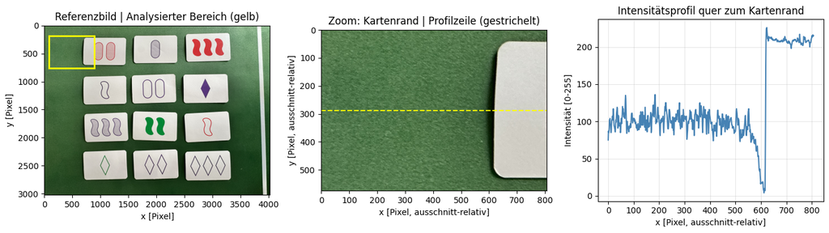

```
Profilbereich: Zeile 287 des Ausschnitts | Intensität: [4, 226] | Lokaler Kontrast: 222
```

```python
from matplotlib.patches import Rectangle

# Ausschnitt: linke Karte, erste Kartenreihe (Kartenrand links sichtbar)
y0, y1 = int(0.06 * H), int(0.25 * H)
x0, x1 = int(0.02 * W), int(0.22 * W)
crop_rgb = img[y0:y1, x0:x1]
crop_gray = img_gray[y0:y1, x0:x1]

# Intensitätsprofil entlang der mittleren Zeile des Ausschnitts
mid_row = crop_gray.shape[0] // 2
profile = crop_gray[mid_row, :]

fig, axes = plt.subplots(1, 3, figsize=(14, 4))

axes[0].imshow(img)
rect = Rectangle(
    (x0, y0), x1 - x0, y1 - y0, linewidth=2, edgecolor="yellow", facecolor="none"
)
axes[0].add_patch(rect)
axes[0].set_title("Referenzbild | Analysierter Bereich (gelb)")
axes[0].set_xlabel("x [Pixel]")
axes[0].set_ylabel("y [Pixel]")

axes[1].imshow(crop_rgb)
axes[1].axhline(y=mid_row, color="yellow", linewidth=1.5, linestyle="--")
axes[1].set_title("Zoom: Kartenrand | Profilzeile (gestrichelt)")
axes[1].set_xlabel("x [Pixel, ausschnitt-relativ]")
axes[1].set_ylabel("y [Pixel, ausschnitt-relativ]")

axes[2].plot(profile, color="steelblue")
axes[2].set_title("Intensitätsprofil quer zum Kartenrand")
axes[2].set_xlabel("x [Pixel, ausschnitt-relativ]")
axes[2].set_ylabel("Intensität [0-255]")
axes[2].grid(True, alpha=0.3)

plt.tight_layout()
plt.show()

print(
    f"Profilbereich: Zeile {mid_row} des Ausschnitts "
    f"| Intensität: [{profile.min()}, {profile.max()}] "
    f"| Lokaler Kontrast: {profile.max() - profile.min()}"
)
```

**Beobachtungen:**

Das Intensitätsprofil zeigt den erwarteten Sprung vom dunklen Untergrund zur hellen Kartenfläche. Der Übergang erfolgt innerhalb weniger Pixel und ist deutlich steiler als die internen Texturvariationen auf der Kartenfläche. Dieser starke, lokalisierte Intensitätswechsel bestätigt, dass die Zielstruktur für den Canny-Algorithmus geeignet ist.

### 1.2.5 Algorithmenbegründung

Der Canny-Algorithmus (Tag 6) ist für diese Zielstruktur aus drei Gründen geeignet:

1. **Gaussian Blur:** Dämpft JPEG-Kompressionsartefakte und lokale Texturvariationen auf der Kartenfläche, ohne die dominanten Kartenrand-Kanten wesentlich zu schwächen.
2. **Non-Maximum Suppression:** Erzeugt exakt ein-Pixel-breite Kanten, was für die spätere geometrische Analyse der Kartenränder erforderlich ist.
3. **Hysteresis Thresholding:** Mit geeignetem `high_threshold` werden nur die starken Karte-Untergrund-Übergänge sicher klassifiziert, schwache Karte-Karte-Grenzen und interne Symboltexturen werden unterdrückt.

Die konkrete Parameter-Konfiguration für das reale SET-Bild wird in Tag 8 erarbeitet.

## 1.3 Tag 8 – Methodisches Design

### 1.3.2 Repräsentativer Bildausschnitt

Für das methodische Design und die spätere Evaluation wird ein einzelner Bildausschnitt verwendet:

[output not shown]

### 1.3.3 Schlüsselparameter

Drei Parameter des Canny-Algorithmus haben den stärksten Einfluss auf das Detektionsergebnis in diesem Bild:

[output not shown]

### 1.3.4 Konfigurationen

[output not shown]

### 1.3.5 Begründung der Konfigurationswahl

- **Baseline vs. Variation 1** zeigt den Effekt von mehr Glättung und höherer Selektivität. Dies ist relevant, weil das Bild einen Helligkeitsgradienten hat: erhöht man `high_threshold`, werden Karten im dunkleren unteren Bildbereich womöglich nicht mehr erkannt.
- **Baseline vs. Variation 2** zeigt den Effekt von weniger Glättung und niedrigerer Selektivität. Dies verdeutlicht, ab wann interne Symboltexturen als Kanten durchdringen.

Viele weitere Parameterkombinationen wären möglich, aber der Erkenntnisgewinn nimmt schnell ab. Zwei gezielte Variationen sind ausreichend, um die Empfindlichkeit des Algorithmus gegenüber den zwei Hauptproblemen dieses Bildes – Beleuchtungsgradient und interne Texturkanten – zu bewerten.

## 1.4 Tag 9 – Evaluation

### 1.4.1 Evaluationsmass

Als einziges quantitatives Mass wird die **Kantendichte** (Edge Density) des gesamten Ausschnitts verwendet:

$$\rho = \frac{\text{Anzahl Kantenpixel}}{\text{Gesamtpixel im Ausschnitt}} \times 100 \; [\%]$$

**Definition:** $\rho$ gibt an, welcher Anteil der Pixel im Ausschnitt als Kantenpixel klassifiziert wird.

**Eignung:** Für die Kartenrand-Detektion ist eine kompakte, präzise Kantenmenge erwünscht. Zu hohe Kantendichte zeigt, dass der Algorithmus Rausch- und Texturkanten einschliesst; zu niedrige Kantendichte deutet auf verpasste Kartenränder hin. Das Mass ist direkt über alle Konfigurationen vergleichbar, benötigt keine Ground-Truth-Labels und ist unabhängig von der genauen Lage einzelner Strukturen im Ausschnitt.

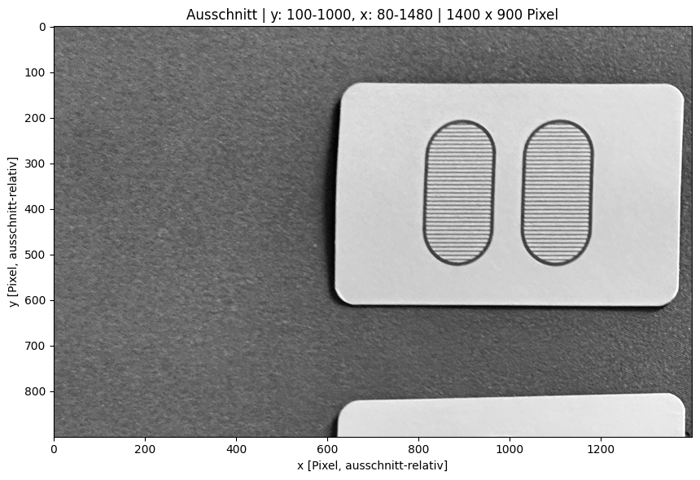

```
Ausschnitt: 1400 x 900 = 1,260,000 Pixel
```

```python
import numpy as np
import matplotlib.pyplot as plt
import cv2
from pathlib import Path
from PIL import Image

IMG_PATH = Path("..") / "data" / "IMG_6947.JPG"
img_gray = np.array(Image.open(IMG_PATH).convert("L"))

# Ausschnitt: linke zwei Karten, erste Reihe
Y0, Y1, X0, X1 = 100, 1000, 80, 1480
crop = img_gray[Y0:Y1, X0:X1]
H_c, W_c = crop.shape

# Konfigurationen aus Tag 8
CONFIGS = {
    "Baseline": dict(sigma=1.5, high=120, low=40),
    "Variation 1": dict(sigma=2.5, high=160, low=53),
    "Variation 2": dict(sigma=1.0, high=80, low=27),
}

fig, ax = plt.subplots(figsize=(10, 6))
ax.imshow(crop, cmap="gray", vmin=0, vmax=255)
ax.set_title(f"Ausschnitt | y: {Y0}-{Y1}, x: {X0}-{X1} | {W_c} x {H_c} Pixel")
ax.set_xlabel("x [Pixel, ausschnitt-relativ]")
ax.set_ylabel("y [Pixel, ausschnitt-relativ]")
plt.tight_layout()
plt.show()

print(f"Ausschnitt: {W_c} x {H_c} = {W_c * H_c:,} Pixel")
```

### 1.4.2 Anwendung auf alle Konfigurationen

Der Canny-Algorithmus (Gaussian Blur + `cv2.Canny` mit `L2gradient=True`, wie in Tag 6 verifiziert) wird auf den Ausschnitt angewendet. Die Kantendichte $\rho$ wird für jede Konfiguration berechnet.

```python
def apply_canny(gray, sigma, low, high):
    ksize = max(5, 2 * int(2 * sigma) + 1)  # ungerade, >= 5
    blurred = cv2.GaussianBlur(gray, (ksize, ksize), sigmaX=sigma)
    return cv2.Canny(blurred, threshold1=low, threshold2=high, L2gradient=True)


results = {}
edge_maps = {}

for name, cfg in CONFIGS.items():
    edges = apply_canny(crop, cfg["sigma"], cfg["low"], cfg["high"])
    edge_maps[name] = edges
    n_edge = int((edges > 0).sum())
    rho = n_edge / edges.size * 100
    results[name] = dict(
        sigma=cfg["sigma"], high=cfg["high"], low=cfg["low"], n_edge=n_edge, rho=rho
    )

baseline_rho = results["Baseline"]["rho"]

print(
    f"{'Konfiguration':<14} {'sigma':>6} {'high':>5} {'low':>5} "
    f"{'Kantenpixel':>12} {'rho [%]':>8} {'Delta rho [%]':>14}"
)
print("-" * 72)
for name, r in results.items():
    delta = r["rho"] - baseline_rho
    delta_str = f"{delta:+.3f}" if name != "Baseline" else "--"
    print(
        f"{name:<14} {r['sigma']:>6.1f} {r['high']:>5} {r['low']:>5} "
        f"{r['n_edge']:>12,} {r['rho']:>8.3f} {delta_str:>14}"
    )
```

```
Konfiguration   sigma  high   low  Kantenpixel  rho [%]  Delta rho [%]
------------------------------------------------------------------------
Baseline          1.5   120    40       23,503    1.865             --
Variation 1       2.5   160    53        7,280    0.578         -1.288
Variation 2       1.0    80    27      115,773    9.188         +7.323
```

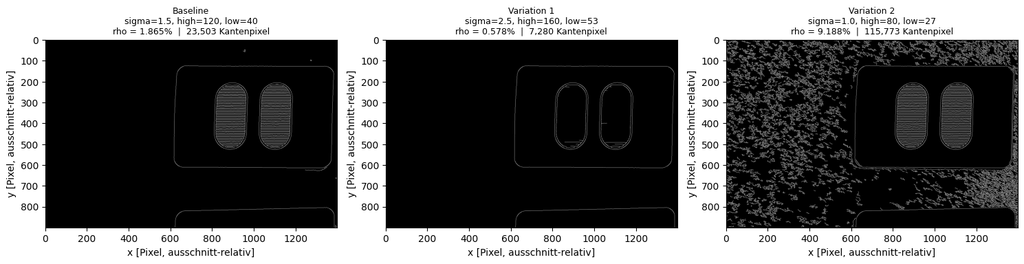

```python
fig, axes = plt.subplots(1, 3, figsize=(15, 5))
for ax, (name, edges) in zip(axes, edge_maps.items()):
    cfg = CONFIGS[name]
    r = results[name]
    ax.imshow(edges, cmap="gray")
    ax.set_title(
        f"{name}\n"
        f"sigma={cfg['sigma']}, high={cfg['high']}, low={cfg['low']}\n"
        f"rho = {r['rho']:.3f}%  |  {r['n_edge']:,} Kantenpixel",
        fontsize=9,
    )
    ax.set_xlabel("x [Pixel, ausschnitt-relativ]")
    ax.set_ylabel("y [Pixel, ausschnitt-relativ]")
plt.tight_layout()
plt.show()
```

### 1.4.3 Vergleich gegenüber Baseline

Die Werte aus der obigen Tabelle quantifizieren die Unterschiede zwischen den Konfigurationen:

- **Delta rho (Variation 1 vs. Baseline):** Ein positiver Wert bedeutet mehr Kantenpixel trotz höherer Schwellen; ein negativer Wert zeigt stärkere Unterdrückung.
- **Delta rho (Variation 2 vs. Baseline):** Niedrigere Schwellen schliessen mehr Kanten ein; ein positiver Delta zeigt die Zunahme an Kantenpixeln.

Die Differenzen (Delta rho) sind in der Tabelle ausgewiesen. Konfigurationen mit $\Delta\rho > 0$ produzieren mehr Kantenpixel als die Baseline; $\Delta\rho < 0$ bedeutet eine stärkere Unterdrückung.

## 1.5 Tag 10 – Analyse & Kommunikation

*Wird an Tag 10 vervollständigt.*

## 1.6 Quellenverzeichnis

[1] J. Canny, “A Computational Approach to Edge Detection,” *IEEE Transactions on Pattern Analysis and Machine Intelligence*, vol. PAMI-8, no. 6, pp. 679-698, Nov. 1986.